# cyclistic_case_study_v2

Svyatoslav Lunyaka

2025-07-04

## 🧭 Introduction

This project aims to apply and consolidate foundational data analysis skills through a comprehensive case study of a fictional bike-share company. It guides the full data analysis workflow — from data preparation to actionable insights — demonstrating practical competence and readiness for professional roles.

- **What is Cyclistic?** Cyclistic is a fictional bike-share company providing shared bicycles for short-term urban rentals. The service focuses on convenient, affordable, and eco-friendly transportation for residents and visitors.
- **Business task from stakeholders** Stakeholders seek to increase Cyclistic’s rider base by understanding user behavior, identifying key segments, and discovering opportunities to boost engagement.
- **My role and deliverables** As a data analyst, I am responsible for cleaning, processing, and analyzing the data to produce actionable, data-driven recommendations. I will deliver insights and visualizations supporting strategic decisions to attract more riders.
- **Key guiding question(s)**
  - Who are the main users of Cyclistic bikes?
  - How do different user types (e.g., casual vs. annual members) behave?
  - What temporal patterns influence bike usage?
  - What steps can Cyclistic take to grow its customer base?
- **Summary of my approach** I follow a structured data analysis process: asking questions, preparing and cleaning data, performing exploratory analysis, feature engineering (e.g., calculating trip durations), and visualizing results to uncover patterns. Final deliverables include a comprehensive report with clear recommendations for stakeholder action.

## 📂 Data Description

### Where data comes from

The data originates from Cyclistic’s internal records, collected over several months. It is publicly available for analysis as part of the case study and can be accessed [here](https://divvy-tripdata.s3.amazonaws.com/index.html).

### Description of raw files

The raw data consists of monthly `.csv` files stored in the `data/raw/` directory. Each file contains records of individual bike trips with the following key columns:

| Column Name | Type | Description |
| --- | --- | --- |
| `ride_id` | character | Unique identifier for each trip |
| `rideable_type` | character | Type of bike used (e.g., classic, electric) |
| `started_at` | datetime | Timestamp when the ride started |
| `ended_at` | datetime | Timestamp when the ride ended |
| `start_station_name` | character | Name of the station where the ride started |
| `end_station_name` | character | Name of the station where the ride ended |
| `start_lat` | double | Latitude of the ride start location |
| `start_lng` | double | Longitude of the ride start location |
| `end_lat` | double | Latitude of the ride end location |
| `end_lng` | double | Longitude of the ride end location |
| `member_casual` | character | User type: member or casual |

### Tools & Environment

This project is conducted in **RStudio** using **R Markdown** to ensure transparency, reproducibility, and documentation of the full analytical process. Key packages used include:

- `tidyverse` — data manipulation and visualization
- `lubridate` — date/time processing
- `janitor` — column cleaning and comparison
- `skimr`, `DataExplorer` — data overview and profiling
- `here` — reliable file paths across systems

All computations and visualizations are executed directly within the `.Rmd` file.

## 🛠️ Data Preparation

### Setting Up the Working Environment

To prepare for data analysis, relevant R packages were installed and loaded. These packages provide essential tools for reading, transforming, visualizing, and analyzing data.

```r
# Install necessary packages (run once)
# install.packages(c("tidyverse", "data.table", "lubridate", "janitor", "skimr", "DataExplorer", "here"))

# Load libraries
library(tidyverse)      # data manipulation and visualization
library(data.table)     # fast file loading and handling of large datasets
library(lubridate)      # date-time parsing and manipulation
library(janitor)        # clean column names
library(skimr)          # summary statistics
library(DataExplorer)   # data structure exploration
library(here)           # consistent project folder paths
library(ggplot2)        # data visualization (part of tidyverse, loaded separately for clarity)
```

### Loading and Merging Monthly Data

This section covers loading multiple `.CSV` files from the raw data folder, checking their structure for consistency, and merging them into a single data frame for further analysis.

```r
# Get full paths to all CSV files in the data/raw folder
raw_files <- list.files(
  path = here("data", "raw"),
  pattern = "*.csv",
  full.names = TRUE)

# Check the number of files found
length(raw_files)
```

```
## [1] 12
```

```r
# Preview the first file
sample_df <- read_csv(raw_files[1])
glimpse(sample_df)
```

```
## Rows: 710,721
## Columns: 13
## $ ride_id            <chr> "CDE6023BE6B11D2F", "462B48CD292B6A18", "9CFB6A858D…
## $ rideable_type      <chr> "electric_bike", "electric_bike", "electric_bike", …
## $ started_at         <dttm> 2024-06-11 17:20:06, 2024-06-11 17:19:21, 2024-06-…
## $ ended_at           <dttm> 2024-06-11 17:21:39, 2024-06-11 17:19:36, 2024-06-…
## $ start_station_name <chr> NA, NA, NA, NA, NA, NA, NA, NA, NA, NA, NA, NA, NA,…
## $ start_station_id   <chr> NA, NA, NA, NA, NA, NA, NA, NA, NA, NA, NA, NA, NA,…
## $ end_station_name   <chr> NA, NA, NA, NA, NA, NA, NA, NA, NA, NA, NA, NA, NA,…
## $ end_station_id     <chr> NA, NA, NA, NA, NA, NA, NA, NA, NA, NA, NA, NA, NA,…
## $ start_lat          <dbl> 41.89, 41.89, 41.93, 41.88, 41.94, 41.94, 41.94, 41…
## $ start_lng          <dbl> -87.65, -87.65, -87.65, -87.64, -87.64, -87.64, -87…
## $ end_lat            <dbl> 41.89000, 41.89000, 41.94000, 41.88000, 41.94000, 4…
## $ end_lng            <dbl> -87.65000, -87.65000, -87.65000, -87.64000, -87.640…
## $ member_casual      <chr> "casual", "casual", "casual", "casual", "casual", "…
```

```r
# Function to extract column names (first 10 rows to speed up)
get_column_names <- function(file_path) {
  names(read_csv(file_path, n_max = 10))
}

# Get list of column names for each file
column_lists <- map(raw_files, get_column_names)

# Identify unique column structures
unique_structures <- unique(column_lists)
length(unique_structures)  # Expecting 1 if all files have the same structure
```

```
## [1] 1
```

```r
# Read all files into a list of data frames
list_of_dfs <- map(raw_files, read_csv)

# Combine all data frames into one
all_trips <- bind_rows(list_of_dfs)

# Check the structure of the combined data frame
glimpse(all_trips)
```

```
## Rows: 5,628,847
## Columns: 13
## $ ride_id            <chr> "CDE6023BE6B11D2F", "462B48CD292B6A18", "9CFB6A858D…
## $ rideable_type      <chr> "electric_bike", "electric_bike", "electric_bike", …
## $ started_at         <dttm> 2024-06-11 17:20:06, 2024-06-11 17:19:21, 2024-06-…
## $ ended_at           <dttm> 2024-06-11 17:21:39, 2024-06-11 17:19:36, 2024-06-…
## $ start_station_name <chr> NA, NA, NA, NA, NA, NA, NA, NA, NA, NA, NA, NA, NA,…
## $ start_station_id   <chr> NA, NA, NA, NA, NA, NA, NA, NA, NA, NA, NA, NA, NA,…
## $ end_station_name   <chr> NA, NA, NA, NA, NA, NA, NA, NA, NA, NA, NA, NA, NA,…
## $ end_station_id     <chr> NA, NA, NA, NA, NA, NA, NA, NA, NA, NA, NA, NA, NA,…
## $ start_lat          <dbl> 41.89, 41.89, 41.93, 41.88, 41.94, 41.94, 41.94, 41…
## $ start_lng          <dbl> -87.65, -87.65, -87.65, -87.64, -87.64, -87.64, -87…
## $ end_lat            <dbl> 41.89000, 41.89000, 41.94000, 41.88000, 41.94000, 4…
## $ end_lng            <dbl> -87.65000, -87.65000, -87.65000, -87.64000, -87.640…
## $ member_casual      <chr> "casual", "casual", "casual", "casual", "casual", "…
```

### 🔧 Creating Additional Features

To deepen our analysis, we create several new variables derived from the existing data:

- `ride_duration` — the duration of each trip in seconds
- `day_of_week` — the day of the week when the trip started
- `month` — the month when the trip occurred
- `hour_of_day` — the hour of the day when the trip started

These features will help us uncover temporal patterns in user behavior.

```r
all_trips <- all_trips %>%
  mutate(
    ride_duration = round(as.numeric(difftime(ended_at, started_at, units = "secs"))),
    day_of_week = lubridate::wday(started_at, label = TRUE, abbr = FALSE, week_start = 1),
    day_of_week = factor(day_of_week, levels = c("Monday", "Tuesday", "Wednesday", "Thursday", "Friday", "Saturday", "Sunday"), ordered = TRUE),
    month = factor(lubridate::month(started_at), levels = 1:12, labels = month.name, ordered = TRUE),
    hour_of_day = lubridate::hour(started_at)
  )

# Check the new columns
glimpse(all_trips)
```

```
## Rows: 5,628,847
## Columns: 17
## $ ride_id            <chr> "CDE6023BE6B11D2F", "462B48CD292B6A18", "9CFB6A858D…
## $ rideable_type      <chr> "electric_bike", "electric_bike", "electric_bike", …
## $ started_at         <dttm> 2024-06-11 17:20:06, 2024-06-11 17:19:21, 2024-06-…
## $ ended_at           <dttm> 2024-06-11 17:21:39, 2024-06-11 17:19:36, 2024-06-…
## $ start_station_name <chr> NA, NA, NA, NA, NA, NA, NA, NA, NA, NA, NA, NA, NA,…
## $ start_station_id   <chr> NA, NA, NA, NA, NA, NA, NA, NA, NA, NA, NA, NA, NA,…
## $ end_station_name   <chr> NA, NA, NA, NA, NA, NA, NA, NA, NA, NA, NA, NA, NA,…
## $ end_station_id     <chr> NA, NA, NA, NA, NA, NA, NA, NA, NA, NA, NA, NA, NA,…
## $ start_lat          <dbl> 41.89, 41.89, 41.93, 41.88, 41.94, 41.94, 41.94, 41…
## $ start_lng          <dbl> -87.65, -87.65, -87.65, -87.64, -87.64, -87.64, -87…
## $ end_lat            <dbl> 41.89000, 41.89000, 41.94000, 41.88000, 41.94000, 4…
## $ end_lng            <dbl> -87.65000, -87.65000, -87.65000, -87.64000, -87.640…
## $ member_casual      <chr> "casual", "casual", "casual", "casual", "casual", "…
## $ ride_duration      <dbl> 93, 15, 286, 863, 15, 19, 395, 3858, 18, 21, 677, 1…
## $ day_of_week        <ord> NA, NA, NA, NA, NA, NA, NA, NA, NA, NA, NA, NA, NA,…
## $ month              <ord> June, June, June, June, June, June, June, June, Jun…
## $ hour_of_day        <int> 17, 17, 17, 11, 0, 0, 0, 18, 12, 12, 8, 19, 19, 15,…
```

```r
summary(all_trips$ride_duration)
```

```
##    Min. 1st Qu.  Median    Mean 3rd Qu.    Max.
## -3361.0   326.0   571.0   997.7  1010.0 93595.0
```

```r
str(all_trips)
```

```
## tibble [5,628,847 × 17] (S3: tbl_df/tbl/data.frame)
##  $ ride_id           : chr [1:5628847] "CDE6023BE6B11D2F" "462B48CD292B6A18" "9CFB6A858D23ABF7" "6365EFEB64231153" ...
##  $ rideable_type     : chr [1:5628847] "electric_bike" "electric_bike" "electric_bike" "electric_bike" ...
##  $ started_at        : POSIXct[1:5628847], format: "2024-06-11 17:20:06" "2024-06-11 17:19:21" ...
##  $ ended_at          : POSIXct[1:5628847], format: "2024-06-11 17:21:39" "2024-06-11 17:19:36" ...
##  $ start_station_name: chr [1:5628847] NA NA NA NA ...
##  $ start_station_id  : chr [1:5628847] NA NA NA NA ...
##  $ end_station_name  : chr [1:5628847] NA NA NA NA ...
##  $ end_station_id    : chr [1:5628847] NA NA NA NA ...
##  $ start_lat         : num [1:5628847] 41.9 41.9 41.9 41.9 41.9 ...
##  $ start_lng         : num [1:5628847] -87.7 -87.7 -87.7 -87.6 -87.6 ...
##  $ end_lat           : num [1:5628847] 41.9 41.9 41.9 41.9 41.9 ...
##  $ end_lng           : num [1:5628847] -87.7 -87.7 -87.7 -87.6 -87.6 ...
##  $ member_casual     : chr [1:5628847] "casual" "casual" "casual" "casual" ...
##  $ ride_duration     : num [1:5628847] 93 15 286 863 15 ...
##  $ day_of_week       : Ord.factor w/ 7 levels "Monday"<"Tuesday"<..: NA NA NA NA NA NA NA NA NA NA ...
##  $ month             : Ord.factor w/ 12 levels "January"<"February"<..: 6 6 6 6 6 6 6 6 6 6 ...
##  $ hour_of_day       : int [1:5628847] 17 17 17 11 0 0 0 18 12 12 ...
```

### 🧹 Checking for Missing Values

At this stage, I checked for missing values in the data using the `plot_missing()` function from the **DataExplorer package.** This provides a quick visual overview of which columns contain gaps and how significant they are for the analysis.

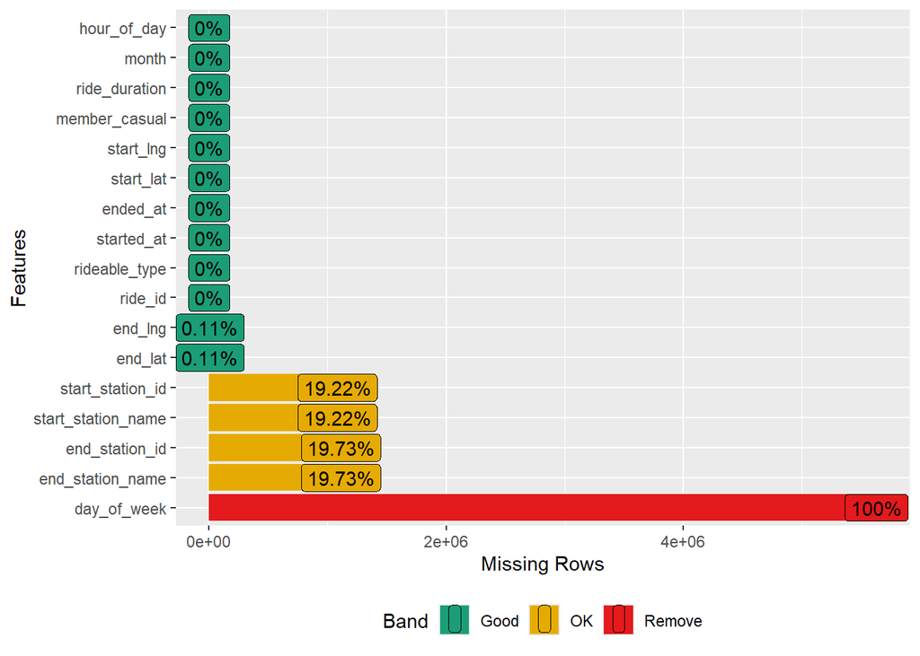

```r
plot_missing(all_trips)
```

The visual inspection confirmed that key columns — such as `started_at`, `ended_at`, `rideable_type`, and `member_casual` — are fully populated with no missing values.

I decided to keep these records in the dataset but will revisit this if I later analyze location-based information.

### ✂️ Ride Duration Cleaning: Outlier Detection & Filtering

Before analyzing ride duration, I first explore potential outliers at both ends of the distribution. I’m not removing any data yet, but I want to understand which thresholds make sense for cleaning.

Lower bound (60 seconds): I consider trips shorter than 1 minute as likely errors — these could be caused by accidental unlocks, test rides, or system glitches, and they probably don’t represent real usage.

Upper bound (24 hours): Trips that last more than 24 hours are extremely rare. I believe they usually result from users forgetting to end the ride or from technical issues during trip recording.

To support this decision, I visualize both ends of the ride duration spectrum using histograms.

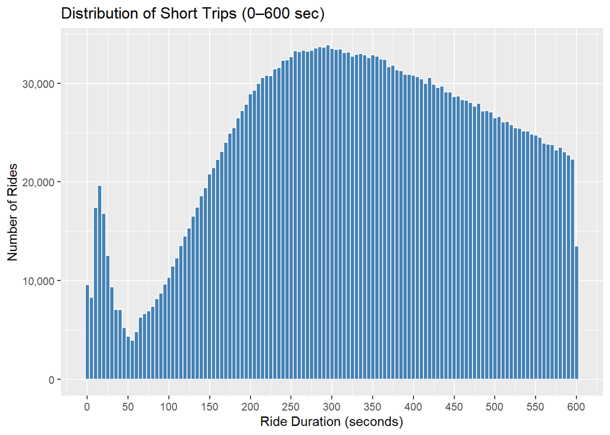

```r
all_trips %>%
  filter(ride_duration >= 0, ride_duration <= 600) %>%
  ggplot(aes(x = ride_duration)) +
  geom_histogram(binwidth = 5, fill = "steelblue", color = "white") +
  scale_x_continuous(breaks = seq(0, 600, 50)) +
  scale_y_continuous(labels = scales::comma) +
  labs(title = "Distribution of Short Trips (0–600 sec)",
       x = "Ride Duration (seconds)", y = "Number of Rides")
```

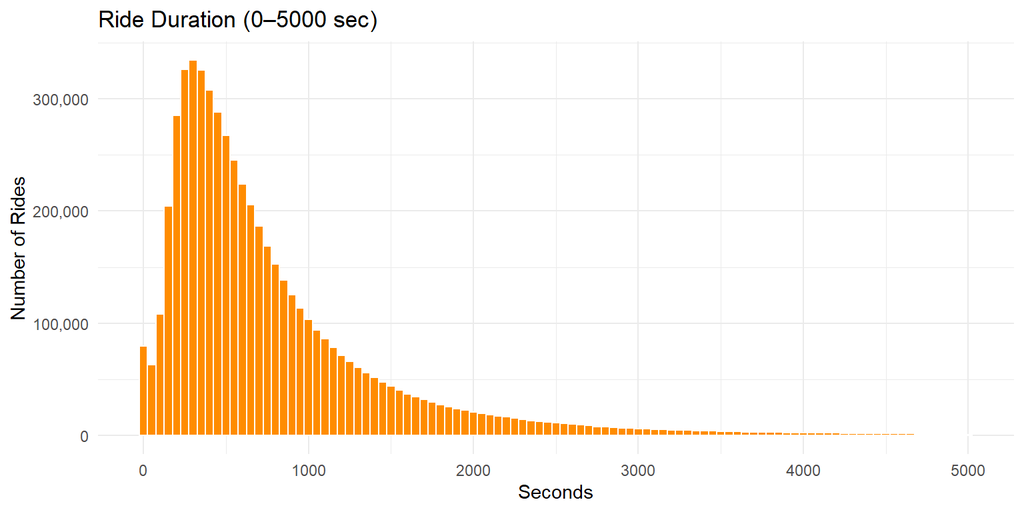

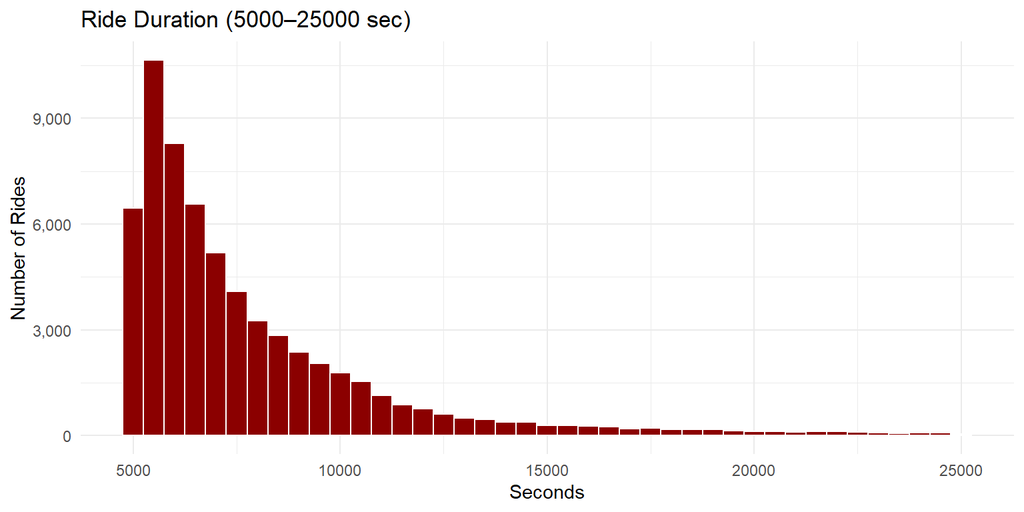

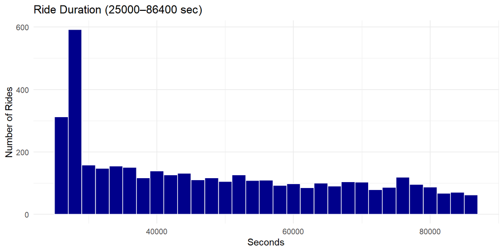

```r
p1 <- all_trips %>%
  filter(ride_duration > 0, ride_duration <= 5000) %>%
  ggplot(aes(x = ride_duration)) +
  geom_histogram(binwidth = 50, fill = "darkorange", color = "white") +
  scale_y_continuous(labels = scales::comma) +
  labs(title = "Ride Duration (0–5000 sec)",
       x = "Seconds",
       y = "Number of Rides") +
  theme_minimal()

p2 <- all_trips %>%
  filter(ride_duration > 5000, ride_duration <= 25000) %>%
  ggplot(aes(x = ride_duration)) +
  geom_histogram(binwidth = 500, fill = "darkred", color = "white") +
  scale_y_continuous(labels = scales::comma) +
  labs(title = "Ride Duration (5000–25000 sec)",
       x = "Seconds",
       y = "Number of Rides") +
  theme_minimal()

p3 <- all_trips %>%
  filter(ride_duration > 25000, ride_duration <= 86400) %>%
  ggplot(aes(x = ride_duration)) +
  geom_histogram(binwidth = 2000, fill = "darkblue", color = "white") +
  scale_y_continuous(labels = scales::comma) +
  labs(title = "Ride Duration (25000–86400 sec)",
       x = "Seconds",
       y = "Number of Rides") +
  theme_minimal()

# Display plots vertically
# The 'patchwork' package can be used for more complex layouts if installed.
# For basic Rmd output, printing plots sequentially will display them.
print(p1)
print(p2)
print(p3)
```

After visually examining the distribution of short trips, I’ll now delve into the `ride_duration` distribution using the Interquartile Range (IQR) method for a more rigorous outlier detection. The IQR method helps me identify values that deviate significantly from the “main” body of the data based on its spread.

Outliers using the IQR method are defined as values that fall: * Below $Q1 - 1.5 \times IQR$ (lower bound) * Above $Q3 + 1.5 \times IQR$ (upper bound)

Where $Q1$ is the first quartile (25th percentile), $Q3$ is the third quartile (75th percentile), and $IQR = Q3 - Q1$.

```r
# Calculate quartiles and IQR for ride_duration
Q1 <- quantile(all_trips$ride_duration, 0.25, na.rm = TRUE)
Q3 <- quantile(all_trips$ride_duration, 0.75, na.rm = TRUE)
IQR_val <- Q3 - Q1

# Calculate the outlier bounds using the IQR method
lower_bound_iqr <- Q1 - 1.5 * IQR_val
upper_bound_iqr <- Q3 + 1.5 * IQR_val

# Print the results
cat("Q1 (25th percentile):", Q1, "seconds\n")
```

```
## Q1 (25th percentile): 326 seconds
```

```r
cat("Q3 (75th percentile):", Q3, "seconds\n")
```

```
## Q3 (75th percentile): 1010 seconds
```

```r
cat("IQR (Interquartile Range):", IQR_val, "seconds\n")
```

```
## IQR (Interquartile Range): 684 seconds
```

```r
cat("Lower bound for outliers (IQR):", lower_bound_iqr, "seconds\n")
```

```
## Lower bound for outliers (IQR): -700 seconds
```

```r
cat("Upper bound for outliers (IQR):", upper_bound_iqr, "seconds\n")
```

```
## Upper bound for outliers (IQR): 2036 seconds
```

```r
# Count trips outside the IQR bounds
outliers_lower_iqr <- sum(all_trips$ride_duration < lower_bound_iqr, na.rm = TRUE)
outliers_upper_iqr <- sum(all_trips$ride_duration > upper_bound_iqr, na.rm = TRUE)

cat("\nNumber of trips below the lower IQR bound:", outliers_lower_iqr, "\n")
```

```
##
## Number of trips below the lower IQR bound: 38
```

```r
cat("Number of trips above the upper IQR bound:", outliers_upper_iqr, "\n")
```

```
## Number of trips above the upper IQR bound: 419432
```

### Justification for Ride Duration Filtering

The results from the IQR analysis provide statistical boundaries for `ride_duration`. Typically, the lower bound derived from the IQR method can often be negative or very low, which isn’t practically useful for metrics like duration (as duration cannot be negative). In our case, any trip less than 0 seconds is already an error.

The upper IQR bound can be quite high, indicating that the “normal” range of rides (without outliers by this method) still includes very long trips. This highlights that while the IQR method is statistically sound, for duration data that may have a strong right skew (many short trips and a few very long ones), **empirical limitations** (e.g., 60 seconds to 24 hours) might be more appropriate for data cleaning from a business logic perspective.

A high count of trips above the upper IQR bound, if identified, suggests a significant number of extremely long rides that could skew averages and other metrics. Therefore, combining statistical analysis (like IQR) with business knowledge (practical thresholds) is the best approach for effective data cleaning.

Based on this, I established clear criteria for cleaning the `ride_duration` data to focus on typical user behavior and ensure the relevance of my analysis for Cyclistic’s business goals.

**My filtering decisions and their rationale:**

1. **Lower Bound: Minimum of 60 seconds.** Rides shorter than 60 seconds (1 minute) are classified as invalid or anomalous. These could be accidental unlocks, test rides, or technical glitches that do not represent genuine service usage. Including such data would skew average duration metrics and overall usage patterns.
2. **Upper Bound: Maximum of 2 hours (7200 seconds).** While statistical IQR analysis might identify significantly shorter rides as “outliers,” **business logic** takes precedence here. A two-hour limit is more realistic for typical urban bike-share trips. Rides exceeding this duration are rare and often indicate atypical usage (e.g., a user forgetting to end a ride) or warrant separate, more detailed investigation, as their large numbers could significantly distort core metrics. By filtering them out, I focus on the behavior of the main user base, which is crucial for forming business recommendations.

These thresholds ensure that my subsequent analysis will be based on a **valid, relevant dataset** that reflects Cyclistic’s primary usage patterns, allowing me to effectively answer key business questions.

### Data Filtering Application

Following the decision on the valid ride duration range, I applied these filters to create a cleaned dataset for all subsequent analyses.

```r
# Create a new, cleaned dataframe by filtering trips
# 1. Ride duration must be greater than or equal to 60 seconds
# 2. Ride duration must be less than or equal to 7200 seconds (2 hours)
cleaned_trips <- all_trips %>%
  filter(ride_duration >= 60, ride_duration <= 7200)

# Check the size and basic characteristics of the new dataframe
glimpse(cleaned_trips)
```

```
## Rows: 5,468,848
## Columns: 17
## $ ride_id            <chr> "CDE6023BE6B11D2F", "9CFB6A858D23ABF7", "6365EFEB64…
## $ rideable_type      <chr> "electric_bike", "electric_bike", "electric_bike", …
## $ started_at         <dttm> 2024-06-11 17:20:06, 2024-06-11 17:25:27, 2024-06-…
## $ ended_at           <dttm> 2024-06-11 17:21:39, 2024-06-11 17:30:13, 2024-06-…
## $ start_station_name <chr> NA, NA, NA, NA, NA, NA, NA, NA, NA, NA, NA, NA, NA,…
## $ start_station_id   <chr> NA, NA, NA, NA, NA, NA, NA, NA, NA, NA, NA, NA, NA,…
## $ end_station_name   <chr> NA, NA, NA, NA, NA, NA, NA, NA, NA, NA, NA, NA, "Wo…
## $ end_station_id     <chr> NA, NA, NA, NA, NA, NA, NA, NA, NA, NA, NA, NA, "63…
## $ start_lat          <dbl> 41.89, 41.93, 41.88, 41.94, 41.91, 41.89, 41.80, 41…
## $ start_lng          <dbl> -87.65, -87.65, -87.64, -87.64, -87.63, -87.62, -87…
## $ end_lat            <dbl> 41.89000, 41.94000, 41.88000, 41.93000, 41.87000, 4…
## $ end_lng            <dbl> -87.65000, -87.65000, -87.64000, -87.64000, -87.610…
## $ member_casual      <chr> "casual", "casual", "casual", "casual", "casual", "…
## $ ride_duration      <dbl> 93, 286, 863, 395, 3858, 677, 128, 99, 1311, 787, 1…
## $ day_of_week        <ord> NA, NA, NA, NA, NA, NA, NA, NA, NA, NA, NA, NA, NA,…
## $ month              <ord> June, June, June, June, June, June, June, June, Jun…
## $ hour_of_day        <int> 17, 17, 11, 0, 18, 8, 19, 19, 15, 19, 0, 21, 12, 19…
```

```r
summary(cleaned_trips$ride_duration)
```

```
##    Min. 1st Qu.  Median    Mean 3rd Qu.    Max.
##    60.0   339.0   580.0   833.9  1011.0  7200.0
```

## 📈 Exploratory Data Analysis (EDA)

After data cleaning, I conducted a detailed exploratory data analysis to answer key business questions regarding Cyclistic user behavior. My goal was to identify differences between members and casual riders, as well as to determine temporal patterns in bike usage.

### 1. User Type Distribution

This chart shows the total number of rides taken by each user type. I found that **members are the main driving force behind Cyclistic**, having completed 3,499,632 rides, which significantly exceeds the 1,969,216 rides by casual users. This highlights the importance of the membership program and the loyalty of existing customers.

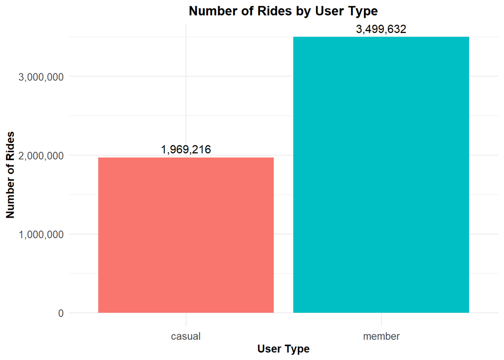

```r
# Plot: Number of Rides by User Type
cleaned_trips %>%
  ggplot(aes(x = member_casual, fill = member_casual)) +
  geom_bar() +
  geom_text(stat = 'count', aes(label = scales::comma(..count..)), vjust = -0.5, size = 4) +
  labs(
    title = "Number of Rides by User Type",
    x = "User Type",
    y = "Number of Rides"
  ) +
  scale_y_continuous(labels = scales::comma) +
  theme_minimal() +
  theme(legend.position = "none",
        plot.title = element_text(hjust = 0.5, face = "bold"),
        axis.title = element_text(face = "bold"),
        axis.text = element_text(size = 10))
```

### 2. Average Ride Duration by User Type

Analyzing the average ride duration, I noticed a clear distinction: **casual** users, on average, **ride significantly longer (1080 seconds or 18 minutes) than members (696 seconds or 11.6 minutes)**. This suggests that casual users likely use bikes for leisure or longer, irregular trips, while members prefer shorter, functional rides.

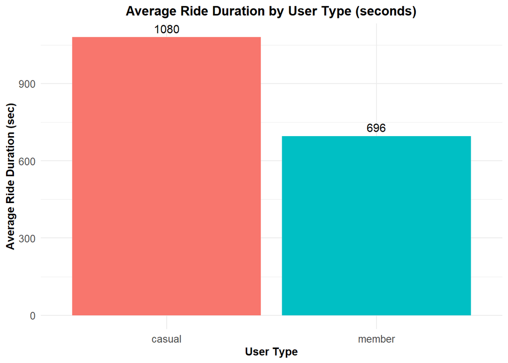

```r
# Plot: Average Ride Duration by User Type
cleaned_trips %>%
  group_by(member_casual) %>%
  summarise(
    avg_ride_duration = mean(ride_duration, na.rm = TRUE)
  ) %>%
  ggplot(aes(x = member_casual, y = avg_ride_duration, fill = member_casual)) +
  geom_col() +
  geom_text(aes(label = round(avg_ride_duration, 0)), vjust = -0.5, size = 4) +
  labs(
    title = "Average Ride Duration by User Type (seconds)",
    x = "User Type",
    y = "Average Ride Duration (sec)"
  ) +
  theme_minimal() +
  theme(legend.position = "none",
        plot.title = element_text(hjust = 0.5, face = "bold"),
        axis.title = element_text(face = "bold"),
        axis.text = element_text(size = 10))
```

### 3. Number of Rides by Day of Week and User Type

[figure not shown]

```r
# Plot: Number of Rides by Day of Week and User Type
cleaned_trips %>%
  ggplot(aes(x = day_of_week, fill = member_casual)) +
  geom_bar(position = "dodge") +
  labs(
    title = "Number of Rides by Day of Week and User Type",
    x = "Day of Week",
    y = "Number of Rides",
    fill = "User Type"
  ) +
  scale_y_continuous(labels = scales::comma) +
  theme_minimal() +
  theme(axis.text.x = element_text(angle = 45, hjust = 1, size = 10),
        plot.title = element_text(hjust = 0.5, face = "bold"),
        axis.title = element_text(face = "bold"),
        axis.text.y = element_text(size = 10))
```

### 4. Number of Rides by Hour of Day and User Type

- **Members** have **two distinct peaks of activity**: a morning peak (around 8:00-9:00 AM) and an evening peak (around 5:00-6:00 PM), typical for commuting.
- **Casual users** show **one broad peak of activity in the afternoon/evening** (approximately from 2:00 PM to 6:00 PM), consistent with usage for leisure, shopping, or tourism.

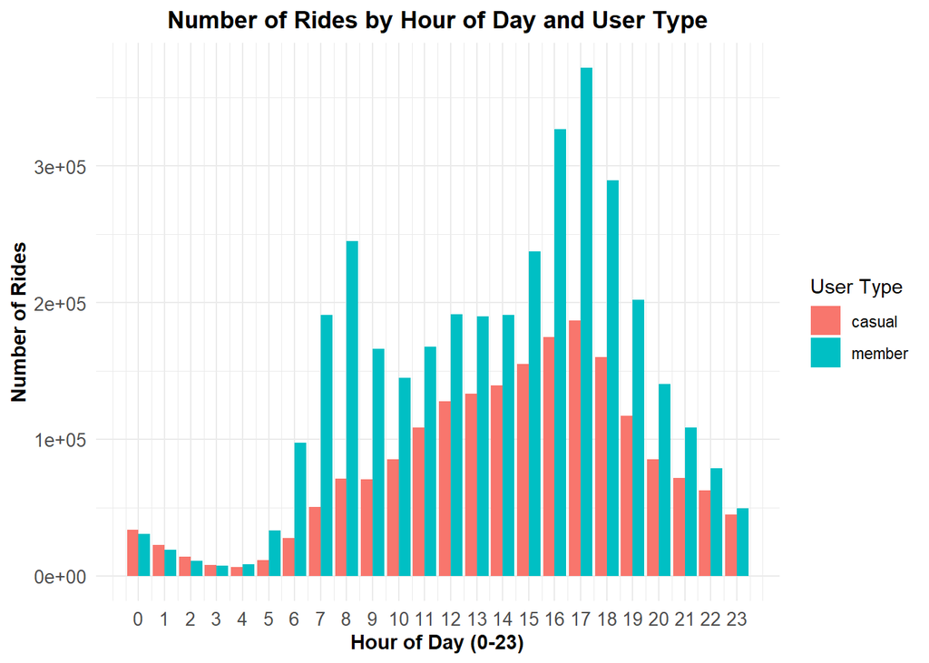

```r
# Plot: Number of Rides by Hour of Day and User Type
cleaned_trips %>%
  ggplot(aes(x = hour_of_day, fill = member_casual)) +
  geom_bar(position = "dodge") +
  labs(
    title = "Number of Rides by Hour of Day and User Type",
    x = "Hour of Day (0-23)",
    y = "Number of Rides",
    fill = "User Type"
  ) +
  scale_x_continuous(breaks = 0:23) +
  theme_minimal() +
  theme(plot.title = element_text(hjust = 0.5, face = "bold"),
        axis.title = element_text(face = "bold"),
        axis.text = element_text(size = 10))
```

### 5. Number of Rides by Month and User Type

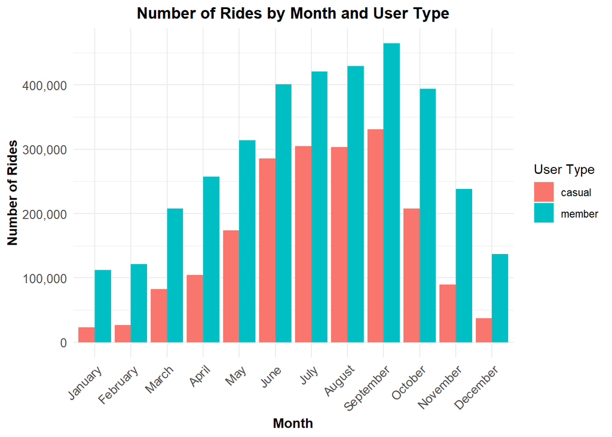

```r
# Plot: Number of Rides by Month and User Type
cleaned_trips %>%
  ggplot(aes(x = month, fill = member_casual)) +
  geom_bar(position = "dodge") +
  labs(
    title = "Number of Rides by Month and User Type",
    x = "Month",
    y = "Number of Rides",
    fill = "User Type"
  ) +
  scale_y_continuous(labels = scales::comma) +
  theme_minimal() +
  theme(axis.text.x = element_text(angle = 45, hjust = 1, size = 10),
        plot.title = element_text(hjust = 0.5, face = "bold"),
        axis.title = element_text(face = "bold"),
        axis.text.y = element_text(size = 10))
```

### 6. Distribution of Bike Types

I analyzed the popularity of different vehicle types:

- **Electric bikes (`electric_bike`)** are the most popular (2,948,738 rides).
- **Classic bikes (`classic_bike`)** are also very popular (2,382,643 rides).
- **Electric scooters (`electric_scooter`)** are used significantly less often (137,467 rides).

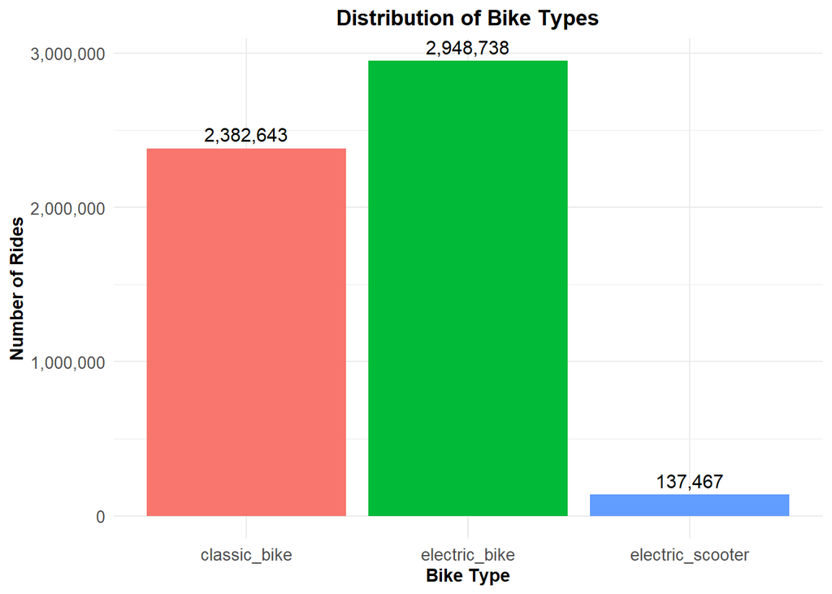

```r
# Plot: Distribution of Bike Types
cleaned_trips %>%
  ggplot(aes(x = rideable_type, fill = rideable_type)) +
  geom_bar() +
  geom_text(stat = 'count', aes(label = scales::comma(..count..)), vjust = -0.5, size = 4) +
  labs(
    title = "Distribution of Bike Types",
    x = "Bike Type",
    y = "Number of Rides"
  ) +
  scale_y_continuous(labels = scales::comma) +
  theme_minimal() +
  theme(legend.position = "none",
        plot.title = element_text(hjust = 0.5, face = "bold"),
        axis.title = element_text(face = "bold"),
        axis.text = element_text(size = 10))
```

### 7. Number of Rides by Bike Type and User Type

This chart revealed the preferences for bike types within each segment:

- **Members** use **electric bikes** significantly more often.
- **Casual users** have a **more balanced usage** between classic and electric bikes, with a slight preference for electric bikes.
- **Electric scooter** usage is low for both groups.

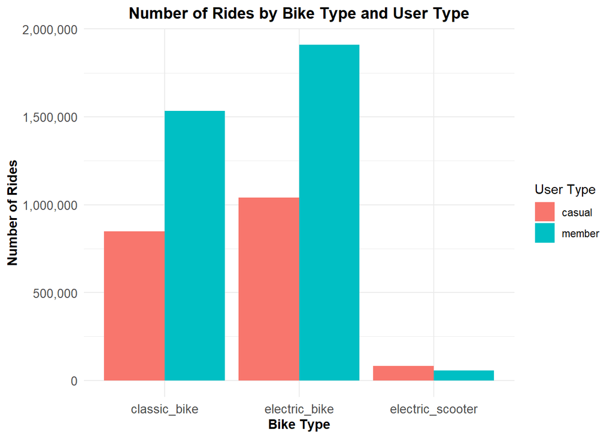

```r
# Plot: Number of Rides by Bike Type and User Type
cleaned_trips %>%
  ggplot(aes(x = rideable_type, fill = member_casual)) +
  geom_bar(position = "dodge") +
  labs(
    title = "Number of Rides by Bike Type and User Type",
    x = "Bike Type",
    y = "Number of Rides",
    fill = "User Type"
  ) +
  scale_y_continuous(labels = scales::comma) +
  theme_minimal() +
  theme(plot.title = element_text(hjust = 0.5, face = "bold"),
        axis.title = element_text(face = "bold"),
        axis.text = element_text(size = 10))
```

### 8. Average Ride Duration by Bike Type and User Type

I found that:

- **Casual users, on average, ride longer on all vehicle types** than members.
- **Casual users’ longest rides are on classic bikes** (1364 seconds), which may indicate their use for extended leisure rides.
- For **members**, rides on electric bikes and electric scooters are relatively shorter, consistent with their use for efficient commutes.

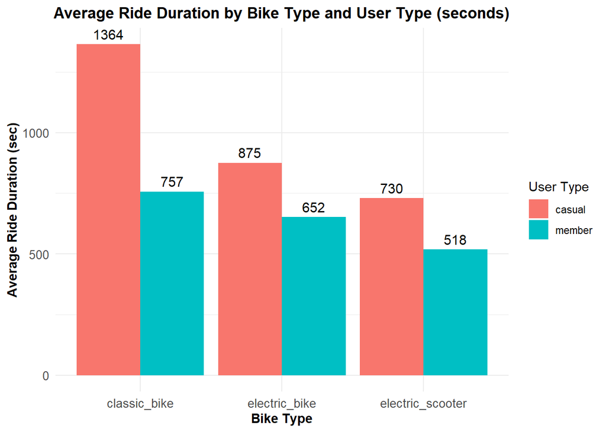

```r
# Plot: Average Ride Duration by Bike Type and User Type
cleaned_trips %>%
  group_by(rideable_type, member_casual) %>%
  summarise(
    avg_ride_duration = mean(ride_duration, na.rm = TRUE)
  ) %>%
  ggplot(aes(x = rideable_type, y = avg_ride_duration, fill = member_casual)) +
  geom_col(position = "dodge") +
  geom_text(aes(label = round(avg_ride_duration, 0)),
            position = position_dodge(width = 0.9), vjust = -0.5, size = 4) +
  labs(
    title = "Average Ride Duration by Bike Type and User Type (seconds)",
    x = "Bike Type",
    y = "Average Ride Duration (sec)",
    fill = "User Type"
  ) +
  theme_minimal() +
  theme(plot.title = element_text(hjust = 0.5, face = "bold"),
        axis.title = element_text(face = "bold"),
        axis.text = element_text(size = 10))
```

## 💡 Recommendations

Based on the comprehensive Exploratory Data Analysis, I can now formulate actionable recommendations for Cyclistic to achieve its business goal of increasing its rider base and boosting engagement. These recommendations are tailored to the distinct behaviors and preferences observed among casual and member riders.

### 1. Convert Casual Riders to Members

The analysis clearly shows that members contribute the majority of rides, but casual riders take longer trips. Converting casual riders to members is a key opportunity for growth.

### 2. Optimize Bike Fleet Management

Understanding bike type preferences and temporal patterns can inform strategic fleet deployment.

### 3. Tailor Marketing Campaigns to User Segments

Different user behaviors require distinct marketing approaches.

- **For Members (Commuters):** Focus marketing on convenience, speed, and cost-effectiveness for daily commutes. Promote the ease of picking up and dropping off bikes, especially during peak hours. Highlight the health and environmental benefits of regular cycling.
- **For Casual Riders (Leisure/Tourism):** Design campaigns around leisure, exploration, and fun. Promote scenic routes, tourist attractions accessible by bike, and weekend adventures. Use imagery that resonates with recreational use (e.g., families cycling, friends exploring).
- **Seasonal Promotions:** Intensify marketing efforts for casual riders during spring and summer months, aligning with their peak usage. Consider “Spring into Cycling” or “Summer Explorer” campaigns. For members, emphasize year-round benefits and offer incentives to continue riding in cooler months.

### 4. Enhance User Experience

Beyond pricing and availability, improving the overall experience can foster loyalty and attract new users.

- **Station Optimization:** Analyze popular start and end stations for both user types and ensure adequate bike availability and docking space, especially during peak times and in high-demand areas (e.g., parks, tourist sites).
- **App Features:** Develop app features that cater to different needs, such as “recommended routes” for casual riders (leisure/scenic) and “fastest commute routes” for members.
- **Customer Feedback:** Implement channels for continuous feedback from both casual and member riders to identify pain points and opportunities for improvement.

## 📄 License

This section outlines the licensing for this project and the data used.

### Project License

This project, including all code, analyses, and written content, is licensed under the **MIT License**.

[output not shown]

### Data License

The dataset used in this case study originates from **Divvy (now Divvy Bikes)**, a public bike-share system. The data is publicly available for analysis and is licensed under the **Divvy Data License Agreement**.

Key aspects of the Divvy Data License typically include:

- Attribution: You must acknowledge Divvy as the source of the data.
- Non-endorsement: You may not use the data in a way that suggests Divvy endorses you or your use of the data.
- No Warranty: The data is provided “as is” without warranty.

For the most up-to-date and complete terms, please refer to the official Divvy data source website, where the data was accessed: https://divvy-tripdata.s3.amazonaws.com/index.html.